# E08 - single-cell RNA-seq (Analysis of Gene Expression @ UCT Prague)

Copy, please, these files and directories to your personal directory:

```bash
cp -r ~/shared/AGE_current/Exercises/E08-scRNA_seq ~/AGE/Exercises
```

# Introduction

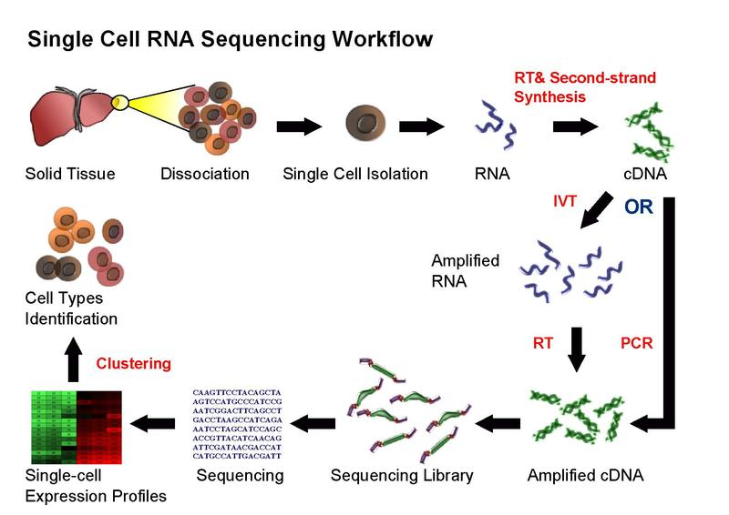

scRNA-seq experiment. [Source](https://scrnaseq-course.cog.sanger.ac.uk)

Taken from [A step-by-step workflow for low-level analysis of single-cell RNA-seq data with Bioconductor](https://f1000research.com/articles/5-2122/v2):

Single-cell RNA sequencing (scRNA-seq) is widely used to measure the genome-wide expression profile of individual cells. Count data are analyzed to detect highly variable genes (HVGs) that drive heterogeneity across cells in a population, to find correlations between genes and cellular phenotypes, or to identify new subpopulations via dimensionality reduction and clustering. This provides biological insights at a single-cell resolution that cannot be achieved with conventional bulk RNA sequencing of cell populations.

Strategies for scRNA-seq data analysis differ markedly from those for bulk RNA-seq. One technical reason is that scRNA-seq data are much noisier than bulk data (Brennecke et al., 2013; Marinov et al., 2014). Reliable capture (i.e., conversion) of transcripts into cDNA for sequencing is difficult with the low quantity of RNA in a single cell (amplification up to 1 million fold!). This increases the frequency of drop-out events where none of the transcripts for a gene are captured. Dedicated steps are required to deal with this noise during analysis, especially during quality control. ScRNA-seq data can be used to study cell-to-cell heterogeneity, e.g., to identify new cell subtypes, to characterize differentiation processes, to assign cells into their cell cycle phases, or to identify highly variable genes (HVGs) driving variability across the population (Fan et al., 2016; Trapnell et al., 2014; Vallejos et al., 2015). This is simply not possible with bulk data, meaning that custom methods are required to perform these analyses.

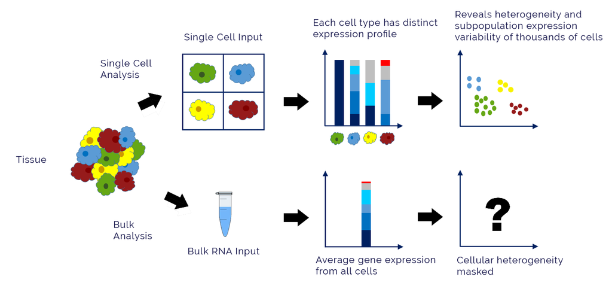

Single-cell vs. bulk RNA-seq. [Source](https://lcsciences.com)

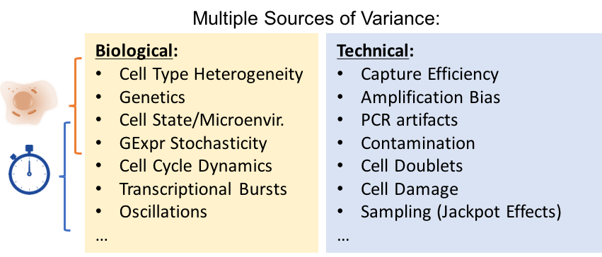

Variance sources in scRNA-seq data - this is why it was (and still is?) a computational challenge. [Source](https://ppapasaikas.github.io/ECCB2018_SC)

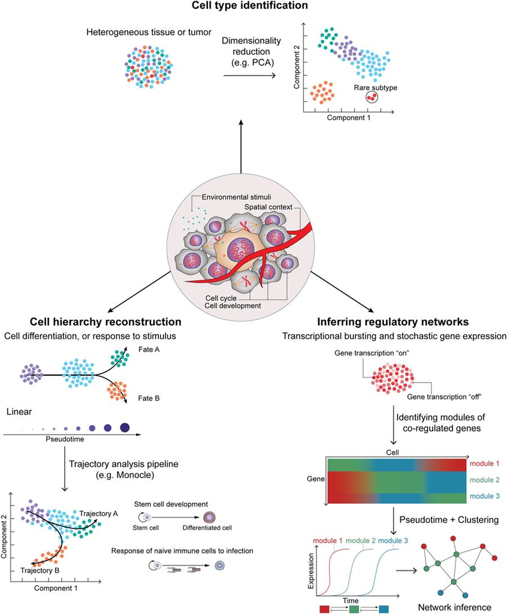

scRNA-seq analysis outputs. With single-cell data, we can do a lot of things which are impossible for bulk RNA-seq, such as cell clustering to reveal new cell subtypes, trajectory inference to observe how cells are differentiating or to reveal novel regulatory mechanisms. Source: Hwang et. al Nature 2018

> This won’t be a normal exercise, but rather a general overview of scRNA-seq data analysis, including links to related tutorials.

## Main tools for scRNA-seq data

Over the last few year, a huge amount of scRNA-seq related tools was released. However, people have started to prefer some of them, probably because they are actively developed, while a lot of tools can be consider dead.

As in the bulk RNA-seq, we can divide tools to

- Read processing - quality control, quantification, etc.
- Downstream analysis - mainly packages in R or Python -> normalization, clustering, differential expression, etc.

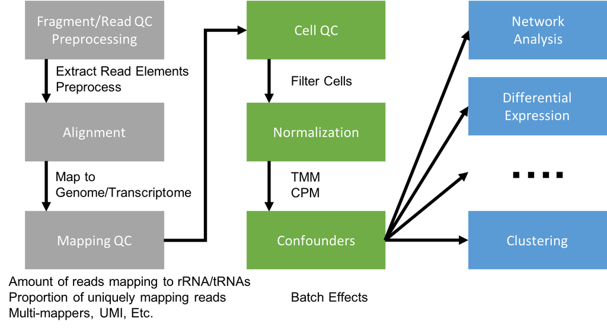

A common scRNA-seq pipeline. Source

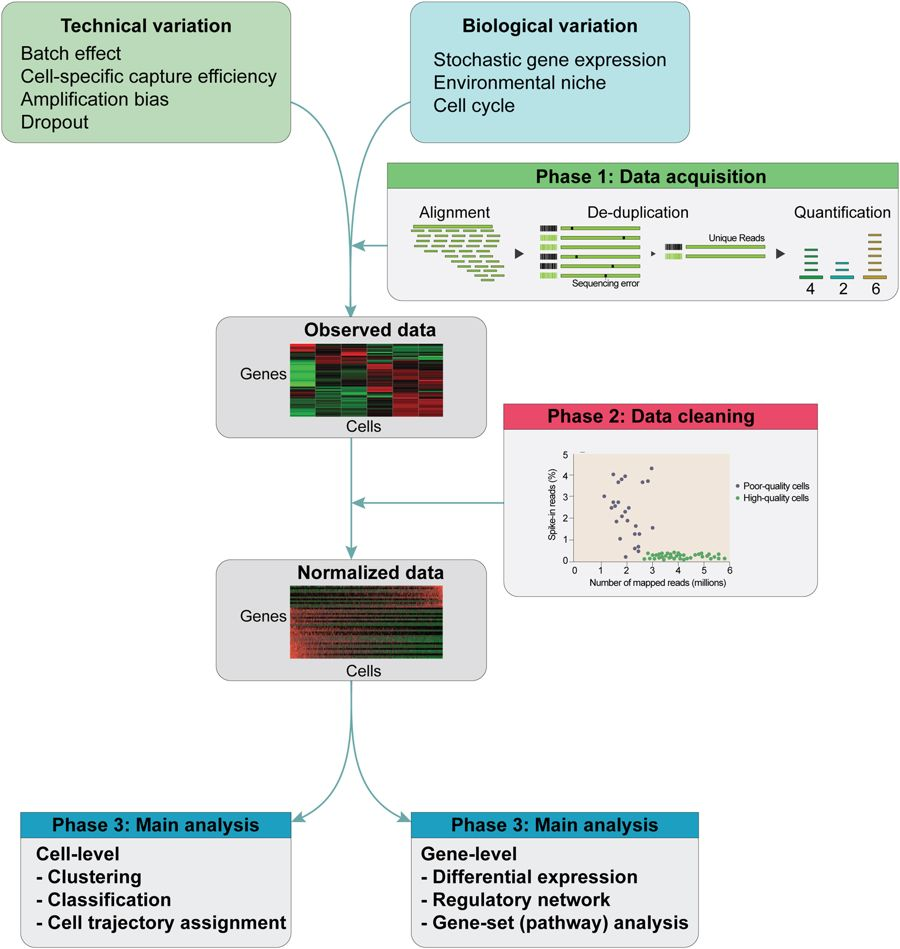

### Read processing

As in the bulk RNA-seq, the goal of read processing is to obtain a count matrix. In case of scRNA-seq, it is often called **gene-barcode matrix**. Barcode is an unique nucleotide sequence, which *should* identify reads (fragments) coming from a single cell. However, it may happen that two or more cells are having the same barcode, and those cases are called doublets.

Because 10x Chromium platform is the leading one in scRNA-seq, we will mainly look at it.

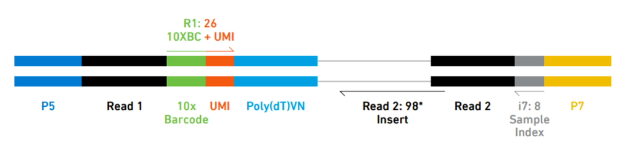

10x read. Read 1 usually contains only technical sequences: adapters, cell barcode and UMI. Read 2 is the biological one. Source

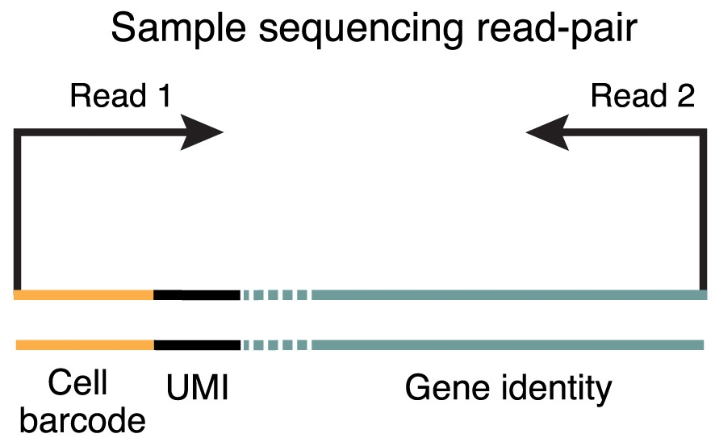

10x read simplified. Source: Macosko et. al Cell 2015

- **Technical quality control**: `FastQC/MultiQC`. Same as in bulk RNA-seq, but be ready to see some SC specific artefacts (like read 1 contains only adapters and barcodes -> nonrandom nucleotides).
- **Trimming**: [generally not recommended](https://www.ncbi.nlm.nih.gov/pmc/articles/PMC4766705/), because quality trimming can negatively impact a downstream analysis. Adapter trimming is OK in case of adapter contamination. You can use the same tools like for bulk RNA-seq, such as `cutadapt` or `trimmomatic`.
- **Cell demultiplexing, alignment/mapping, quantification (i.e. raw reads -> gene-barcode matrix)**:
  - [cellranger](https://support.10xgenomics.com/single-cell-gene-expression/software/pipelines/latest/what-is-cell-ranger). Official and well documented tool for 10x Chromium platform. It should bring you the best results since it uses tuned parameters (specificic for 10x protocol) for external software. For example, it uses special parameters for [bcl2fastq](http://emea.support.illumina.com/sequencing/sequencing_software/bcl2fastq-conversion-software.html) used for obtaining FASTQ from raw Illumina sequencing data. `Cellranger` is parallelized and uses the [Martian](https://martian-lang.org/) language specialized for writing pipelines, so every step in a pipeline is cached and can be resumed. And besides, you obtain a file which can be viewed in another software from 10x, [Loupe Browser](https://support.10xgenomics.com/single-cell-gene-expression/software/visualization/latest/what-is-loupe-cell-browser), which is quite useful and comfortable for biologists.
  - [umitools SC pipeline](https://github.com/CGATOxford/UMI-tools/blob/master/doc/Single_cell_tutorial.md). Umitools are designed for experiments with UMI (Unique Molecular Identifiers). UMI sequence is specified by regex pattern and later appended to FASTA header. Then `STAR`, `HiSat2` or another splice-aware aligner is used. For quantification, `featureCounts` tool from `subread` suite is used. Counts are then collapsed (deduplicated) to UMI level. Finally, UMI counts are corrected with error-correction algorithm.
  - [alevin](https://salmon.readthedocs.io/en/latest/alevin.html). `Alevin` is a part of `Salmon` and is now recommended in above [umitools’ SC pipeline](https://github.com/CGATOxford/UMI-tools/blob/master/doc/Single_cell_tutorial.md). Currently, it supports the following two major droplet based SC protocols: Drop-seq, 10x-Chromium v1/2/3.
  - [dropEst pipeline](https://github.com/hms-dbmi/dropEst). Similar to the `umitools` pipeline.
  - zUMIs. Similar to the `umitools` pipeline. Supports a lot of protocols.

### Downstream analyses

To downstream analyses you enter with a gene-barcode matrix.

Most of SC related packages in the Bioconductor use [SingleCellExperiment](https://bioconductor.org/packages/release/bioc/html/SingleCellExperiment.html) class to store data. This includes specialized methods to store and retrieve spike-in information, dimensionality reduction coordinates and size factors for each cell, along with the usual metadata for genes and libraries. It is similar to `SummarizedExperiment`, but, for example, multiple matrices with different dimensions can be held inside, such as raw and normalized gene-barcode matrix, respectively.

In the past few years, several main packages have been established. They offer a complete toolkit including

- Data structure (gene-barcode matrix, pheno data, etc.). Bioconductor packages are using `SingleCellExperiment` mentioned above.
- Quality control.
- Normalization.
- Visual exploration: plots of cell properties, PCA, tSNE and other dimensionality reduction methods.
- Analysis: clustering, cluster marker genes, differential expression, [trajectory inference](https://en.wikipedia.org/wiki/Trajectory_inference).

We can name some of these packages:

- [Seurat](https://satijalab.org/seurat/). Probably the most popular package with a comfortable interface, offering [tutorials](https://satijalab.org/seurat/vignettes.html) suitable also for R beginners. Surprisingly, it is not a part of the Bioconductor! But developers are smart and `Seurat` can convert between `SingleCellExperiment` and its own `Seurat` object.
- [scran](https://bioconductor.org/packages/release/bioc/html/scran.html). A part of the Bioconductor, offers more functionality than `Seurat`, including low-level stuff. There is a whole book mainly based on `scran`, which I highly recommend: [Orchestrating Single-Cell Analysis with Bioconductor](https://bioconductor.org/books/release/OSCA/). Besides code examples, it also contains a lot of underlying theory, which is very nicely explained.
- scanpy. Written in Python, but also using some R packages through [r2py](https://rpy2.bitbucket.io/). In my opinion, it tends to be similar to `Seurat`, in terms of interface and also tutorials. Like for `Seurat`, there is a great tutorial, which is even published in a [paper](https://www.embopress.org/doi/full/10.15252/msb.20188746). This tutorial and paper are showing the best practices in scRNA-seq data analysis.

### Trajectory inference

Trajectory inference is a part of downstream analysis, but it is quite advanced, and so we won’t go into details now.

From [Wikipedia](https://en.wikipedia.org/wiki/Trajectory_inference):

Trajectory inference or pseudotemporal ordering is a computational technique used in single-cell transcriptomics to determine the pattern of a dynamic process experienced by cells and then arrange cells based on their progression through the process. Single-cell protocols have much higher levels of noise than bulk RNA-seq, so a common step in a single-cell transcriptomics workflow is the clustering of cells into subgroups. Clustering can contend with this inherent variation by combining the signal from many cells, while allowing for the identification of cell types. However, some differences in gene expression between cells are the result of dynamic processes such as the cell cycle, cell differentiation, or response to an external stimuli. Trajectory inference seeks to characterize such differences by placing cells along a continuous path that represents the evolution of the process rather than dividing cells into discrete clusters. In some methods this is done by projecting cells onto an axis called pseudotime which represents the progression through the process.

More reading: [A comparison of single-cell trajectory inference methods (2019)](https://www.nature.com/articles/s41587-019-0071-9)

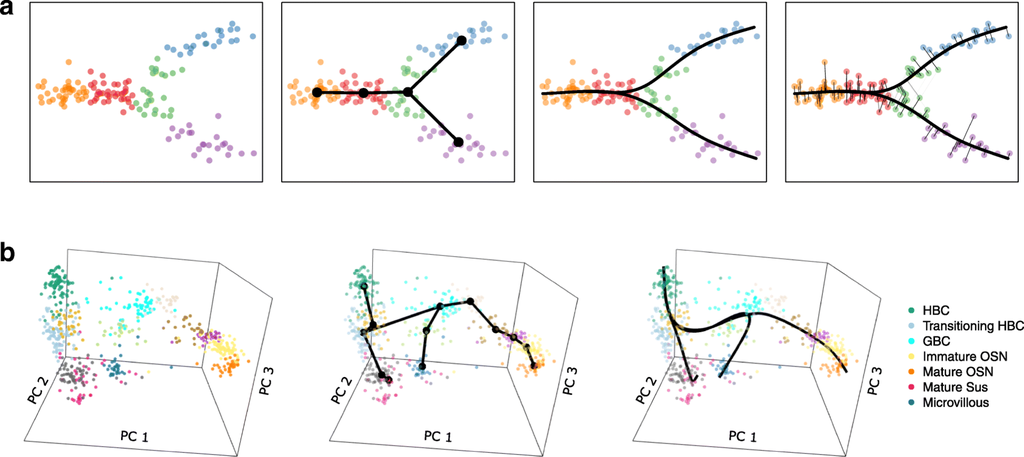

Trajectory inference. [Source](https://en.wikipedia.org/wiki/Trajectory_inference)

Based on the paper above, [dynverse](https://dynverse.org/) was created. This awesome R package offers interface to many trajectory inference packages, which are used internally as Docker images (you won’t directly interact with Docker). These packages also include some non-R ones. As each trajectory inference method is usually suitable for a specific type of scRNA-seq data, there is also an interactive Shiny application in which, based on known cell properties or expected results, you can select the most suitable methods. You can run it through `dynguidelines::guidelines_shiny()` or it is hosted [here](https://zouter.shinyapps.io/server/) (but I don’t know if this is a recent version).

# Tutorials and readings

Besides tutorials for recommended downstream analysis packages above ([Seurat](https://satijalab.org/seurat/vignettes.html), [scanpy](https://github.com/theislab/single-cell-tutorial)), there are some other materials In my opinion, the first one is currently the best, and is also updated frequently.

- [**Orchestrating Single-Cell Analysis with Bioconductor**](https://osca.bioconductor.org/) (OSCA). For now it’s probably the most detailed tutorial. Theory is also well described here. It uses packages from the Bioconductor.
- [A step-by-step workflow for low-level analysis of single-cell RNA-seq data with Bioconductor](https://f1000research.com/articles/5-2122/v2). A peer reviewed tutorial. It is quite detailed and each step of analysis is well explained. It starts from a gene-barcode matrix. A small disadvantage is that this tutorial was lastly revised on 31. October 2016 and many new methods/packages/updates have appeared since then. The first author (Aaron Lun) is the same as for OSCA’s authors.
- [Analysis of single cell RNA-seq data (Hemberg Lab)](https://scrnaseq-course.cog.sanger.ac.uk/website/index.html). Includes SC theory, experimental design and common problems. Analysis goes through quality control, alignment, quantification, filtering, normalization and biological analysis (clustering, DE, pseudotime, etc.).
- [ECCB 2018 Single Cell Tutorial](https://ppapasaikas.github.io/ECCB2018_SC/). Includes some SC theory. It mostly uses a base R, so you get to know how some blackbox functions you are normally using work. This tutorial starts with gene-barcode matrix and goes through quality control, filtering, normalization, clustering and DE.
- [Single-cell RNA sequencing technologies and bioinformatics pipelines (2018)](https://www.nature.com/articles/s12276-018-0071-8). A review of scRNA-seq processing, very nice illustrations.

## Lists

Some URL lists to various SC materials/softwares:

- [Awesome single-cell](https://github.com/seandavi/awesome-single-cell)
- [scRNA-tools](https://www.scrna-tools.org/)
- [List of SC packages in Bioconductor](https://www.bioconductor.org/packages/release/BiocViews.html#___SingleCell)

# Exercise

`Seurat` offers so pretty [tutorial](https://satijalab.org/seurat/articles/pbmc3k_tutorial.html) that we decided to go with it 🙂

Just some useful links:

- `Seurat` [cheatsheet](https://satijalab.org/seurat/articles/essential_commands.html).
- [sctransform](https://satijalab.org/seurat/articles/sctransform_vignette.html) - a recent normalization method.
- [Visualization](https://satijalab.org/seurat/articles/visualization_vignette.html).
- [Conversions](https://satijalab.org/seurat/articles/conversion_vignette.html) to other data formats (e.g. `SingleCellExperiment`).

# HTML rendering

This chunk is not evaluated (`eval = FALSE`). Otherwise you will probably end up in recursive hell 🤯

```r
library(conflicted)
library(knitr)
library(here)

if (!require(rmdformats)) {
  BiocManager::install("rmdformats")
}

# You can set global chunk options. Options set in individual chunks will override this.
opts_chunk$set(warning = FALSE, message = FALSE, eval = TRUE)
rmarkdown::render(
  here("E08-scRNA_seq/scRNA_seq.Rmd"),
  output_file = here("E08-scRNA_seq/scRNA_seq.html"),
  envir = new.env(),
  knit_root_dir = here()
)
```